# Reproducible Research: Peer Assessment 1

## Data

#### *Dataset:*

- activity.csv (17,568 obs)

#### *Variables:*

- steps: Number of steps taking in a 5-minute interval (missing values are coded as NA)
- date: The date on which the measurement was taken in YYYY-MM-DD format
- interval: Identifier for the 5-minute interval in which measurement was taken

## Loading and preprocessing the data

#### *Load the data (i.e. read.csv())*

```r
     data <- read.csv("activity.csv")
```

#### *Process/transform the data (if necessary) into a format suitable for your analysis.*

```r
     allsteps <- aggregate(steps~date, data=data, sum, na.rm=T)
```

## What is mean total number of steps taken per day?

#### *Make a histogram of the total number of steps taken each day.*

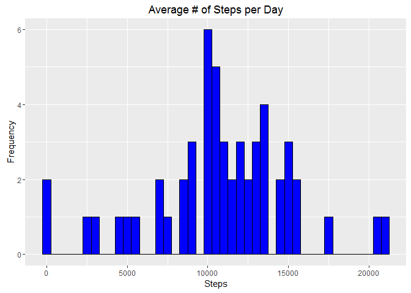

```r
     library(ggplot2)
     qplot(steps,
           data = allsteps,
           geom = "histogram",
           xlab = "Steps",
           ylab = "Frequency",
           main = "Average # of Steps per Day",
           binwidth = 500,
           col = I("black"),
           fill = I("blue")
           )
```

#### *Calculate and report the mean and median of the total number of steps taken per day.*

```r
     meanstep <- format(mean(allsteps$steps), scientific = F)
     medianstep <- median(allsteps$steps)
```

- The mean total number of steps per day:
  - **10766.19** steps.
- The median total number of steps per day:
  - **10765** steps.

## What is the average daily activity pattern?

#### *Make a time series plot of the 5-minute interval (x-axis) & the average number of steps taken, averaged across all days (y-axis).*

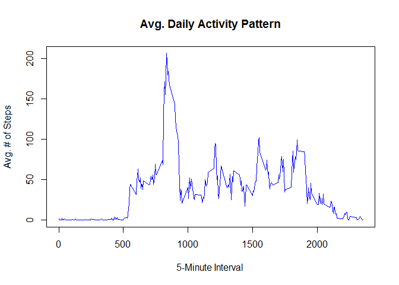

```r
     interval <- aggregate(steps~interval, data=data, mean, na.rm=T)
     plot(steps~interval,
          data = interval,
          type = "l",
          xlab = "5-Minute Interval ",
          ylab = "Avg. # of Steps",
          main = "Avg. Daily Activity Pattern",
          col = "blue"
          )
```

#### *Which 5-minute interval, on average across all the days in the dataset, contains the maximum number of steps?*

```r
     maxint <- interval$interval[which.max(interval$steps)]
```

- The interval with the highest average # of steps is **835**.

## Imputing missing values

#### *Calculate and report the total number of missing values in the dataset.*

```r
     nacount <- sum(is.na(data$steps))
```

- There are a total of **2304** rows with missing data.

#### *Fill in missing values in the dataset (using 5-minute interval). Create new dataset without missing data.*

```r
     nafill <- data
     nafill$steps[is.na(nafill$steps)] <- tapply(nafill$steps, nafill$interval, mean, na.rm=T)
```

#### *Make a histogram of the total # of steps taken each day.*

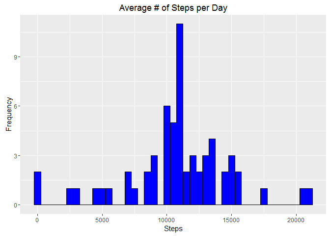

```r
     nonasteps <- aggregate(steps~date, data=nafill, sum)
     qplot(steps,
           data = nonasteps,
           geom = "histogram",
           xlab = "Steps",
           ylab = "Frequency",
           main = "Average # of Steps per Day",
           binwidth = 500,
           col = I("black"),
           fill = I("blue")
           )
```

#### *Calculate total mean & median # of steps per day.*

```r
     nonameanstep <- format(mean(nonasteps$steps), scientific = F)
     nonamedianstep <- format(median(nonasteps$steps), scientific = F)
```

- The mean total number of steps per day (with NAs filled in):
  - **10766.19** steps.
- The median total number of steps per day (with NAs filled in):
  - **10766.19** steps.

#### *Do these values differ from earlier estimates? What is the impact of imputing missing data?*

- There is a minimal difference shown within the median by imputing missing data.

## Are there differences in activity patterns between weekdays and weekends?

#### *Create new variable in dataset with two levels – “weekday” and “weekend”.*

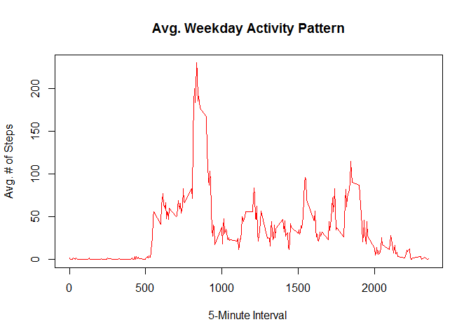

```r
     #add day variable to dataset & define weekday vs. weekday
     nafill$day <- weekdays(as.Date(as.character(nafill$date)))

     nafill$grp <- as.factor(c("Weekend","Weekday"))
     weekendvar <- nafill$day == "Saturday" | nafill$day == "Sunday"

     nafill$grp[!weekendvar] = "Weekday"
     nafill$grp[weekendvar] = "Weekend"

     weekday <- nafill[nafill$grp == "Weekday",]
     weekend <- nafill[nafill$grp == "Weekend",]

     stepdays <- aggregate(steps~interval, weekday, mean)
     stepends <- aggregate(steps~interval, weekend, mean)

     plot(stepdays,
          type = "l",
          col = "red",
          xlab = "5-Minute Interval ",
          ylab = "Avg. # of Steps",
          main = "Avg. Weekday Activity Pattern"
          )
```

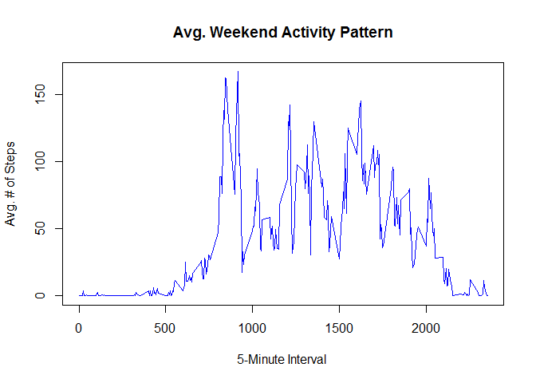

```r
     plot(stepends,
          type = "l",
          col = "blue",
          xlab = "5-Minute Interval ",
          ylab = "Avg. # of Steps",
          main = "Avg. Weekend Activity Pattern"
          )
```